# TP2

Omar Hanley, Zachary Rosen, Todd Schaffer, and Yannan Zhu

April 22, 2020

# Kaggle Competition: NFL Big Data Bowl

Link below to the actual Kaggle Competition:

https://www.kaggle.com/c/nfl-big-data-bowl-2020

A link to our presentation:

https://www.youtube.com/watch?v=ub6SSKVDkZc&feature=youtu.be

# Critique of Select Notebooks

1. R Starter Notebook with 15x Faster Prediction Loop - Part 1 critque link: https://www.kaggle.com/dmitriyguller/r-starter-notebook-with-15x-faster-prediction-loop
2. TestTry Notebook - RMD Part 2 critque link: https://www.kaggle.com/zachanhalt/testtry

# Our Solution

### Preprocessing

As with any machine learning problem, we must first load packages, examine, and preprocess the data

```r
rm(list=ls())
library(ISLR)
library(leaps)
library(splines)
library(randomForest)
library(MASS)
```

We must create a set of indices to split the training data on

```r
df_train <- read.csv('train.csv')

n <- nrow(df_train)
train.indices.split <- sample(n, .8 * n)
```

Now, we must split the response variable from the X variables and omit any NA’s

```r
rusherid <- df_train[, 24]
rusher <- df_train[, 4:10] # speed, angle, distance, coordinates...

# Y variable
yards <- df_train[, 32]

# X variables
rusher <- df_train[, 4:10]
ydLine <- df_train$YardLine
possess <- df_train$PossessionTeam
down <- df_train$Down
dist <- df_train$Distance
form <- df_train$OffenseFormation
defense <- df_train$DefendersInTheBox
direction <- df_train$PlayDirection
weight <- df_train$PlayerWeight
homeTeam <- df_train$HomeTeamAbbr
newDFTrain <- cbind(rusherid, rusher, ydLine, possess, down, dist,
                    form, defense, direction, weight, homeTeam, yards)
newDFTrain <- na.omit(newDFTrain)
train.x <- newDFTrain[train.indices.split, ]
test.x <- newDFTrain[-train.indices.split, ]
train.y <- newDFTrain$yards[train.indices.split]
test.y <- newDFTrain$yards[-train.indices.split]
```

### Fitting A Model

We fit a linear model on all the variables other than yards, which we are using as a response variable

```r
lm_mod <- lm(yards~., data=newDFTrain)
```

### Calculating the test MSE

We will now calculate the test MSE for our first model so we can compare it to the other models we will create later.

```r
ypred <- predict(lm_mod,test.x)
resid <- ypred-test.y
model1_MSE <- mean((resid)^2)
model1_MSE
[1] 40.36604
```

### Subset Selection

While our model currently has an R-Squared of around .019, much of the data may be explained by a few of the X variables as opposed to all the ones we have included.

We will perform forward stepwise selection in order to find better subsets of the data that may explain the information with less additional information

```r
regfit.full = regsubsets(yards~., data=train.x, nvmax=28, method="forward")
coef(regfit.full, 10)
(Intercept)      ydLine  possessDET   possessNO  possessNYJ   possessTB
 7.25773355  0.02312361 -0.50723441  0.53626589 -0.48805182 -0.68238493
       dist formSHOTGUN     defense homeTeamCAR homeTeamCHI
 0.07575567 -0.22677921 -0.60925494  0.67740840 -0.74649804
```

```r
lm_mod1 <- lm(yards~ rusherid + ydLine + possess + dist + form + defense + homeTeam, data=newDFTrain)
ypred <- predict(lm_mod1,test.x)
```

### Calculating the test MSE

We will now calculate the test MSE of our second model to see how it compares to our first models test MSE.

```r
ypred <- predict(lm_mod1,test.x)
resid <- ypred-test.y
model2_MSE <- mean((resid)^2)
model2_MSE
[1] 40.37819
```

### Smoothing Spline

While we have a model that runs previously, we would like to explore non-linear methods as most real world data isn’t exactly linear.

Using the variable that appears in every subset of the regsubsets() function, Defenders, which directly translated to defensive players in the box we create a smoothing spline to predict yards.

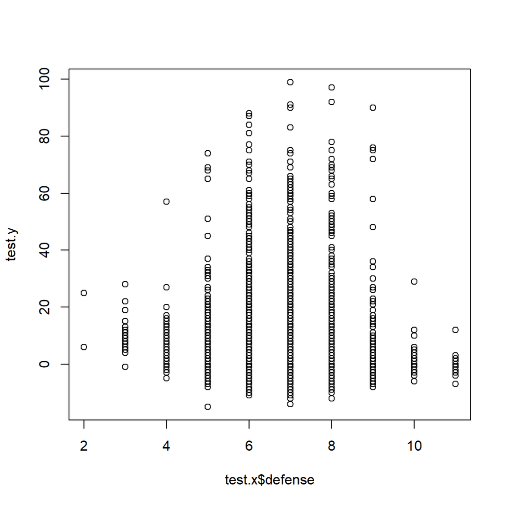

```r
train.x <- na.omit(train.x)
fit2 <- smooth.spline(train.x$yards, train.x$defense, cv=TRUE)
Warning in smooth.spline(train.x$yards, train.x$defense, cv = TRUE): cross-
validation with non-unique 'x' values seems doubtful
fit2_preds <- predict(fit2, x=train.x$defense)

plot(test.x$defense, test.y)
```

### Calculating the test MSE for the Smoothing Spline

We will now calculate the test MSE for the smoothing spline to see if we have improved the result of our model. We will then create a dataframe so we can compare all of the test MSEs of every model we ran.

```r
model3_MSE <- mean((fit2_preds$y-test.y)^2)

all_model_MSEs <- data.frame(model1_MSE, model2_MSE, model3_MSE)
all_model_MSEs
  model1_MSE model2_MSE model3_MSE
1   40.36604   40.37819   47.31803
```